# Sesión 6 - Cointegración Univariada

#### Paso 2: Estimación de los residuales de la regresión en niveles.

La teoría económica sugiere que el tipo de cambio real bajo PPA debe ser uno, así que al sacar logaritmos nos queda e = log(p)-log(p*)

```r
R.1 <- dynlm(e ~ lp.j + lp.u)
summary(R.1)
```

```
##
## Time series regression with "ts" data:
## Start = 1974(1), End = 2012(12)
##
## Call:
## dynlm(formula = e ~ lp.j + lp.u)
##
## Residuals:
##      Min       1Q   Median       3Q      Max
## -0.41312 -0.10770 -0.01184  0.08863  0.42784
##
## Coefficients:
##             Estimate Std. Error t value Pr(>|t|)
## (Intercept)  9.97459    0.36593  27.258   <2e-16 ***
## lp.j        -0.10420    0.10667  -0.977    0.329
## lp.u        -0.76823    0.04505 -17.054   <2e-16 ***
## ---
## Signif. codes:  0 '***' 0.001 '**' 0.01 '*' 0.05 '.' 0.1 ' ' 1
##
## Residual standard error: 0.156 on 465 degrees of freedom
## Multiple R-squared:  0.8336, Adjusted R-squared:  0.8329
## F-statistic:  1165 on 2 and 465 DF,  p-value: < 2.2e-16
```

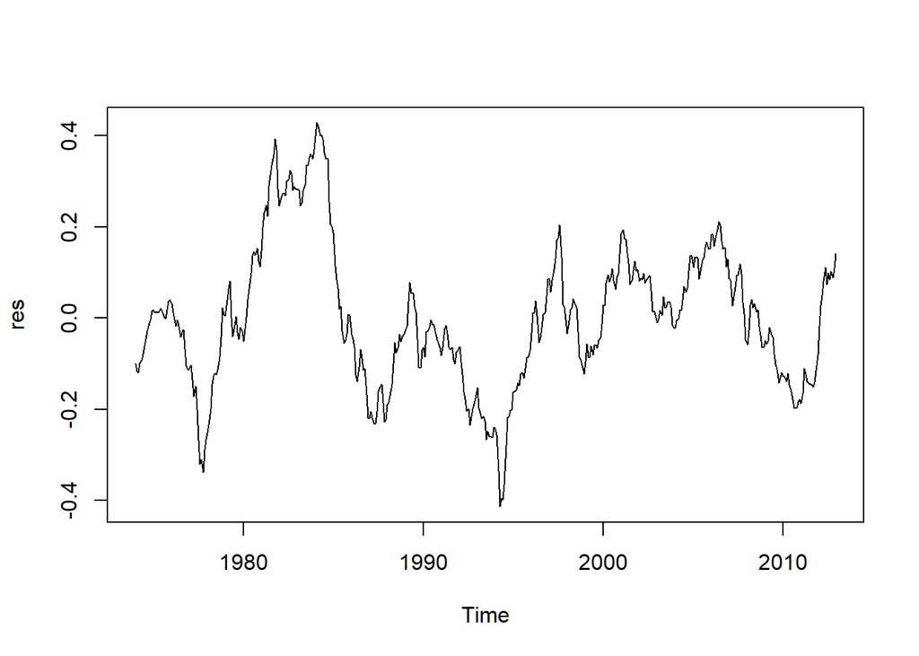

```r
#Obtenemos los residuales
res <- residuals(R.1)

#Graficamos los residuales y analizamos su ACF y PACF
plot.ts(res)
```

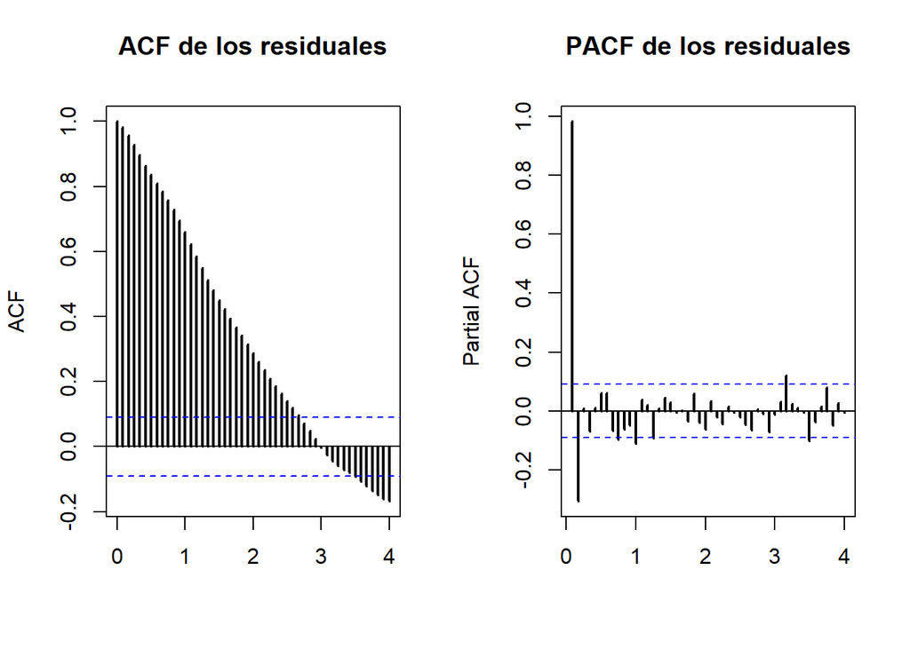

```r
lags=48
par(mfrow=c(1,2))
acf(res,lag.max=lags,plot=T,lwd=2,xlab='',main='ACF de los residuales')
pacf(res,lag.max=lags,plot=T,lwd=2,xlab='',main='PACF de los residuales')
```

```r
#Haremos la prueba ADF sin términos determinísticos.
adf16=ur.df(res, lags=12,type = "none") #Los residuales son estacionarios: hay cointegración.
summary(adf16)
```

```
##
## ###############################################
## # Augmented Dickey-Fuller Test Unit Root Test #
## ###############################################
##
## Test regression none
##
##
## Call:
## lm(formula = z.diff ~ z.lag.1 - 1 + z.diff.lag)
##
## Residuals:
##       Min        1Q    Median        3Q       Max
## -0.087659 -0.015498  0.001659  0.018145  0.071247
##
## Coefficients:
##               Estimate Std. Error t value Pr(>|t|)
## z.lag.1      -0.027330   0.008413  -3.249  0.00125 **
## z.diff.lag1   0.330682   0.046929   7.046 7.09e-12 ***
## z.diff.lag2  -0.031497   0.049152  -0.641  0.52198
## z.diff.lag3   0.074680   0.049236   1.517  0.13004
## z.diff.lag4   0.031550   0.049407   0.639  0.52344
## z.diff.lag5  -0.055529   0.049366  -1.125  0.26127
## z.diff.lag6  -0.046929   0.049637  -0.945  0.34495
## z.diff.lag7   0.003314   0.049787   0.067  0.94696
## z.diff.lag8   0.109516   0.049750   2.201  0.02823 *
## z.diff.lag9   0.056963   0.050026   1.139  0.25546
## z.diff.lag10  0.009979   0.049985   0.200  0.84186
## z.diff.lag11  0.154642   0.049900   3.099  0.00207 **
## z.diff.lag12 -0.039889   0.048261  -0.827  0.40895
## ---
## Signif. codes:  0 '***' 0.001 '**' 0.01 '*' 0.05 '.' 0.1 ' ' 1
##
## Residual standard error: 0.02556 on 442 degrees of freedom
## Multiple R-squared:  0.175,  Adjusted R-squared:  0.1507
## F-statistic: 7.211 on 13 and 442 DF,  p-value: 7.892e-13
##
##
## Value of test-statistic is: -3.2487
##
## Critical values for test statistics:
##       1pct  5pct 10pct
## tau1 -2.58 -1.95 -1.62
```

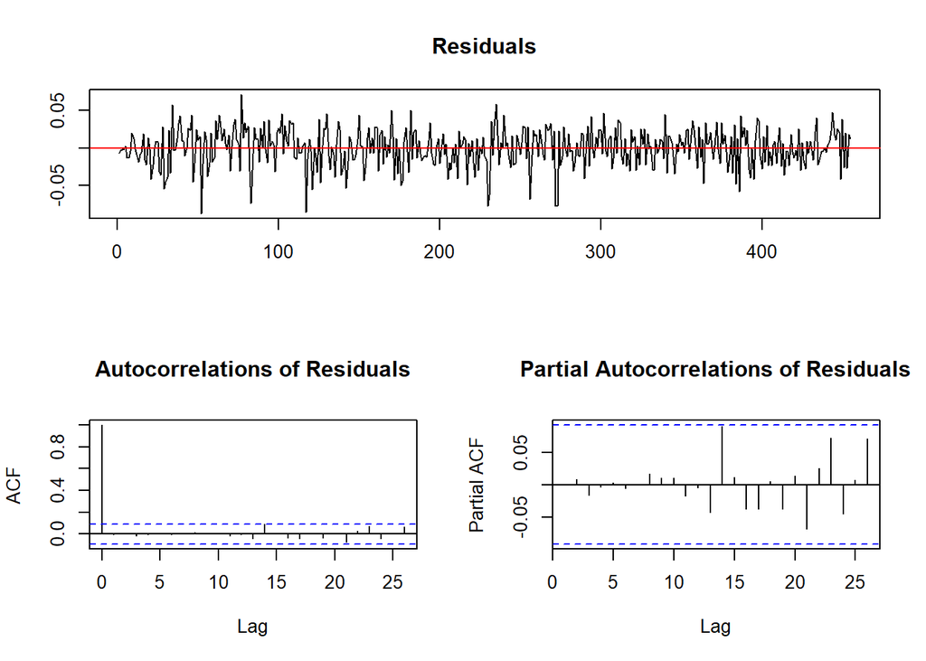

```r
plot(adf16)
```

Recordar que los valores criticos para la prueba de engle-granger son distintos a los valores criticos de una ADF convencional dado que hubo una estimacion anterior de primera etapa. Dichos valores se encuentran en la tabla del Enders, incluyendo 3 variables en la relación de cointegración

```r
coint.test(e, cbind(lp.j, lp.u),nlag = 12)
```

```
## Response: e
## Input: cbind(lp.j, lp.u)
## Number of inputs: 2
## Model: y ~ X + 1
## -------------------------------
## Engle-Granger Cointegration Test
## alternative: cointegrated
##
## Type 1: no trend
##     lag      EG p.value
## 12.0000 -3.4305  0.0443
## -----
##  Type 2: linear trend
##     lag      EG p.value
##  12.000   0.212   0.100
## -----
##  Type 3: quadratic trend
##     lag      EG p.value
##  12.000  -0.329   0.100
## -----------
## Note: p.value = 0.01 means p.value <= 0.01
##     : p.value = 0.10 means p.value >= 0.10
```

####Paso 3: Modelo de Corrección de errores. Para este ejemplo solo estimaremos la primera ecuación. Introduciremos 5 rezagos de cada variable por supuesto. En realidad deberían comparar varios modelos con diferentes especificaciones por medio del AIC y determinar el mejor

```r
#Sin incluir la constante en el término de corrección de error.
VEC_EQ1 <- dynlm(d(e) ~  L(e-0.10420*lp.j -0.76823*lp.u ) + L(d(lp.j), 0:5) + L(d(lp.u), 0:5) + L(d(e), 1:5));summary(VEC_EQ1) #El parámetro de velocidad de ajuste alpha tiene el signo esperado
```

```
##
## Time series regression with "ts" data:
## Start = 1974(7), End = 2012(12)
##
## Call:
## dynlm(formula = d(e) ~ L(e - 0.1042 * lp.j - 0.76823 * lp.u) +
##     L(d(lp.j), 0:5) + L(d(lp.u), 0:5) + L(d(e), 1:5))
##
## Residuals:
##       Min        1Q    Median        3Q       Max
## -0.095999 -0.014575  0.002091  0.019160  0.070305
##
## Coefficients:
##                                        Estimate Std. Error t value Pr(>|t|)
## (Intercept)                           -0.007148   0.002777  -2.574   0.0104 *
## L(e - 0.1042 * lp.j - 0.76823 * lp.u) -0.004866   0.002877  -1.691   0.0915 .
## L(d(lp.j), 0:5)0                      -0.333713   0.267482  -1.248   0.2128
## L(d(lp.j), 0:5)1                      -0.099664   0.263404  -0.378   0.7053
## L(d(lp.j), 0:5)2                      -0.040708   0.273056  -0.149   0.8816
## L(d(lp.j), 0:5)3                      -0.220844   0.262609  -0.841   0.4008
## L(d(lp.j), 0:5)4                       0.165370   0.256609   0.644   0.5196
## L(d(lp.j), 0:5)5                      -0.097105   0.249372  -0.389   0.6972
## L(d(lp.u), 0:5)0                       0.553023   0.519094   1.065   0.2873
## L(d(lp.u), 0:5)1                       0.553507   0.596846   0.927   0.3542
## L(d(lp.u), 0:5)2                      -0.093117   0.597225  -0.156   0.8762
## L(d(lp.u), 0:5)3                       0.270924   0.596695   0.454   0.6500
## L(d(lp.u), 0:5)4                       0.088466   0.593002   0.149   0.8815
## L(d(lp.u), 0:5)5                       0.367280   0.521531   0.704   0.4817
## L(d(e), 1:5)1                          0.324925   0.047145   6.892  1.9e-11 ***
## L(d(e), 1:5)2                         -0.057538   0.049673  -1.158   0.2474
## L(d(e), 1:5)3                          0.044280   0.049770   0.890   0.3741
## L(d(e), 1:5)4                          0.014287   0.050138   0.285   0.7758
## L(d(e), 1:5)5                         -0.105459   0.047595  -2.216   0.0272 *
## ---
## Signif. codes:  0 '***' 0.001 '**' 0.01 '*' 0.05 '.' 0.1 ' ' 1
##
## Residual standard error: 0.02593 on 443 degrees of freedom
## Multiple R-squared:  0.136,  Adjusted R-squared:  0.1009
## F-statistic: 3.875 on 18 and 443 DF,  p-value: 2.184e-07
```

```r
stargazer(VEC_EQ1, type = "text")
```

```
##
## =================================================================
##                                           Dependent variable:
##                                       ---------------------------
##                                                  d(e)
## -----------------------------------------------------------------
## L(e - 0.1042 * lp.j - 0.76823 * lp.u)           -0.005*
##                                                 (0.003)
##
## L(d(lp.j), 0:5)0                                -0.334
##                                                 (0.267)
##
## L(d(lp.j), 0:5)1                                -0.100
##                                                 (0.263)
##
## L(d(lp.j), 0:5)2                                -0.041
##                                                 (0.273)
##
## L(d(lp.j), 0:5)3                                -0.221
##                                                 (0.263)
##
## L(d(lp.j), 0:5)4                                 0.165
##                                                 (0.257)
##
## L(d(lp.j), 0:5)5                                -0.097
##                                                 (0.249)
##
## L(d(lp.u), 0:5)0                                 0.553
##                                                 (0.519)
##
## L(d(lp.u), 0:5)1                                 0.554
##                                                 (0.597)
##
## L(d(lp.u), 0:5)2                                -0.093
##                                                 (0.597)
##
## L(d(lp.u), 0:5)3                                 0.271
##                                                 (0.597)
##
## L(d(lp.u), 0:5)4                                 0.088
```

[output cut: 16 more lines]

```
##
## L(d(e), 1:5)5                                  -0.105**
##                                                 (0.048)
##
## Constant                                       -0.007**
##                                                 (0.003)
##
## -----------------------------------------------------------------
## Observations                                      462
## R2                                               0.136
## Adjusted R2                                      0.101
## Residual Std. Error                        0.026 (df = 443)
## F Statistic                             3.875*** (df = 18; 443)
## =================================================================
## Note:                                 *p<0.1; **p<0.05; ***p<0.01
```

```r
#Incluyendo la constante en el término de corrección de error.
VEC_EQ1.cons <- dynlm(d(e) ~  L(e-9.97459 -0.10420*lp.j  -0.76823*lp.u ) + L(d(lp.j), 0:5) + L(d(lp.u), 0:5) + L(d(e), 1:5));summary(VEC_EQ1.cons) #El parámetro de velocidad de ajuste alpha tiene el signo esperado
```

```
##
## Time series regression with "ts" data:
## Start = 1974(7), End = 2012(12)
##
## Call:
## dynlm(formula = d(e) ~ L(e - 9.97459 - 0.1042 * lp.j - 0.76823 *
##     lp.u) + L(d(lp.j), 0:5) + L(d(lp.u), 0:5) + L(d(e), 1:5))
##
## Residuals:
##       Min        1Q    Median        3Q       Max
## -0.095999 -0.014575  0.002091  0.019160  0.070305
##
## Coefficients:
##                                                  Estimate Std. Error t value
## (Intercept)                                     -0.055682   0.030480  -1.827
## L(e - 9.97459 - 0.1042 * lp.j - 0.76823 * lp.u) -0.004866   0.002877  -1.691
## L(d(lp.j), 0:5)0                                -0.333713   0.267482  -1.248
## L(d(lp.j), 0:5)1                                -0.099664   0.263404  -0.378
## L(d(lp.j), 0:5)2                                -0.040708   0.273056  -0.149
## L(d(lp.j), 0:5)3                                -0.220844   0.262609  -0.841
## L(d(lp.j), 0:5)4                                 0.165370   0.256609   0.644
## L(d(lp.j), 0:5)5                                -0.097105   0.249372  -0.389
## L(d(lp.u), 0:5)0                                 0.553023   0.519094   1.065
## L(d(lp.u), 0:5)1                                 0.553507   0.596846   0.927
## L(d(lp.u), 0:5)2                                -0.093117   0.597225  -0.156
## L(d(lp.u), 0:5)3                                 0.270924   0.596695   0.454
## L(d(lp.u), 0:5)4                                 0.088466   0.593002   0.149
## L(d(lp.u), 0:5)5                                 0.367280   0.521531   0.704
## L(d(e), 1:5)1                                    0.324925   0.047145   6.892
## L(d(e), 1:5)2                                   -0.057538   0.049673  -1.158
## L(d(e), 1:5)3                                    0.044280   0.049770   0.890
## L(d(e), 1:5)4                                    0.014287   0.050138   0.285
## L(d(e), 1:5)5                                   -0.105459   0.047595  -2.216
##                                                 Pr(>|t|)
## (Intercept)                                       0.0684 .
## L(e - 9.97459 - 0.1042 * lp.j - 0.76823 * lp.u)   0.0915 .
## L(d(lp.j), 0:5)0                                  0.2128
## L(d(lp.j), 0:5)1                                  0.7053
## L(d(lp.j), 0:5)2                                  0.8816
## L(d(lp.j), 0:5)3                                  0.4008
## L(d(lp.j), 0:5)4                                  0.5196
## L(d(lp.j), 0:5)5                                  0.6972
## L(d(lp.u), 0:5)0                                  0.2873
## L(d(lp.u), 0:5)1                                  0.3542
## L(d(lp.u), 0:5)2                                  0.8762
## L(d(lp.u), 0:5)3                                  0.6500
## L(d(lp.u), 0:5)4                                  0.8815
## L(d(lp.u), 0:5)5                                  0.4817
## L(d(e), 1:5)1                                    1.9e-11 ***
## L(d(e), 1:5)2                                     0.2474
## L(d(e), 1:5)3                                     0.3741
## L(d(e), 1:5)4                                     0.7758
## L(d(e), 1:5)5                                     0.0272 *
## ---
## Signif. codes:  0 '***' 0.001 '**' 0.01 '*' 0.05 '.' 0.1 ' ' 1
##
## Residual standard error: 0.02593 on 443 degrees of freedom
## Multiple R-squared:  0.136,  Adjusted R-squared:  0.1009
## F-statistic: 3.875 on 18 and 443 DF,  p-value: 2.184e-07
```